# Entropic Assessment of Multiclass Classifiers

Francisco J Valverde  
Sun Feb 22 13:55:05 2015

### Problems with Classifier Evaluation

In multiclass tasks it is often the case that the class distribution is deeply *unbalanced*.

In this case, the usual assessment tools, like **Accuracy** are overly optimistic (*think of a classifier specializing in the majority class!*)

I am going to introduce one exploratory analysis tool, the **Entropy Triangle** which suggest that **Mutual Information** helps understand this effect (and correct it!)

- F. J. Valverde-Albacete and C. Peláaez-Moreno. 100% classification accuracy considered harmful: the normalized information transfer factor explains the accuracy paradox. PLOS ONE, 2014.

### Entropy Balance of a Joint Distribution

Given two discrete R.V. \( X \) and \( Y \), the entropies related to them can be decomposed as:

\[ \log |X| + \log |Y| = \Delta{H_{P_X \cdot P_Y}} + 2\cdot MI_{P_{XY}} + (H_{P_{X|Y}} + H_{P_{Y|X}}) \]

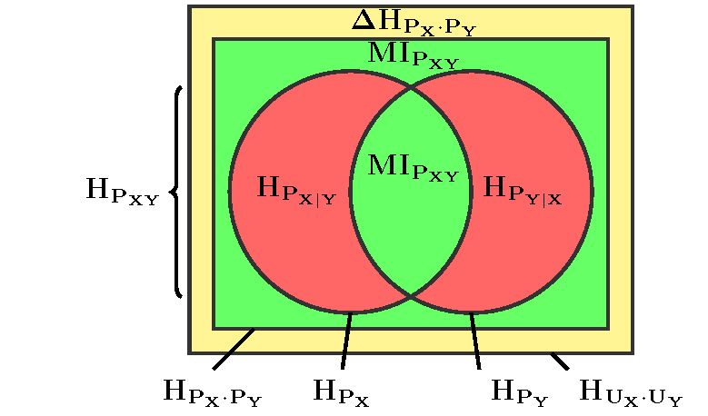

### The Entropy Triangle

We represent the confusion matrices in normalized coordinates \[ 1 = \Delta{H'_{P_X \cdot P_Y}} + 2\cdot MI'_{P_{XY}} + VI'_{P_{XY}} \] in the Entropy Triangle, which is a De Finetti diagram:

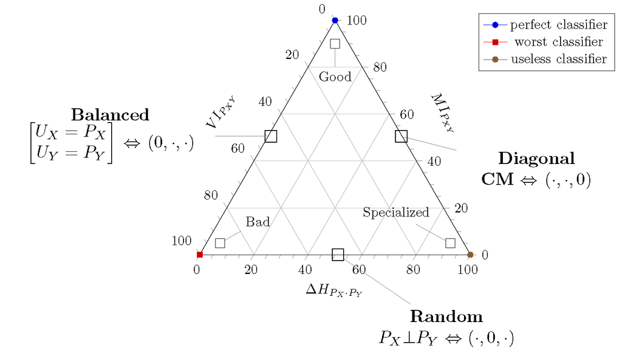

### Example: different classifiers on unbalanced versions of Anderson's iris

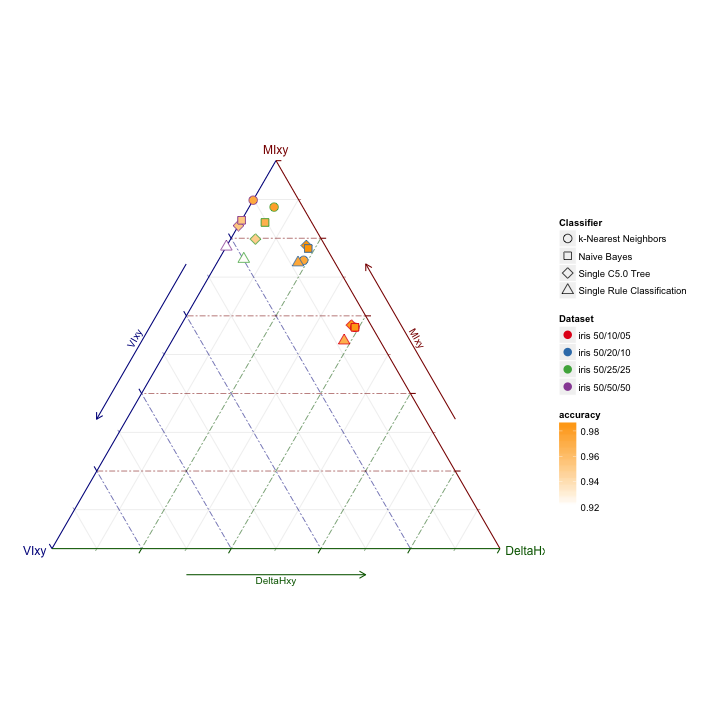

- Using unbalanced datasets:
1. Improves classification Accuracy…! (For different families of classifiers!)
2. But decreases information transmitted in classification process.
- Take-home advice: always use balanced datasets to evaluate classifiers!